# Titanic-ML

Paulyna Magana

Last modified: 19 Sep 2021

# Survival on the Titanic

The sinking of the Titanic is one of the most infamous shipwrecks in history.

On April 15, 1912, during her maiden voyage, the widely considered “unsinkable” RMS Titanic sank after colliding with an iceberg. Unfortunately, there weren’t enough lifeboats for everyone onboard, resulting in the death of 1502 out of 2224 passengers and crew.

While there was some element of luck involved in surviving, it seems some groups of people were more likely to survive than others.

Build a predictive model that answers the question: “what sorts of people were more likely to survive?” using passenger data (ie name, age, gender, socio-economic class, etc).

### Load packages

```r
pkgs <- c("ggplot", "dplyr", "randomForest", "skimr", "tidyverse", "scales", "mice")

# Install:
#install.packages(pkgs)

# Load:
library("knitr")
library("dplyr")
library("ggplot2") #visualization
library("randomForest") #predict
library("skimr") #skim data
library("tidyverse")
library("scales") #dollar scale
library("mice") #predcit
library("corrplot")
library("data.table")
theme_set(theme_classic())
```

First we have to load the dataset.

```r
### Import data with Na for empty observations

train <- read.csv("train.csv", stringsAsFactors = F, na.strings=c("", "NA"))
test <- read.csv("test.csv", stringsAsFactors = F, na.strings=c("", "NA"))
```

Lets join test and train data set but lets add a column to know fron which dataset is every record.

```r
train$set <- "train"
test$set <- "test"
full<- bind_rows(train,test) #bind training& test data
```

### Take a look at the data

```r
dim(full) # dataset dimensions
```

```
## [1] 1309   13
```

```r
# I prefer skim function to check data variables and records.
skim(full) %>%
  select(-(numeric.p0:numeric.p100)) %>%
  select(-(complete_rate))
```

Data summary

| Name | full |
| --- | --- |
| Number of rows | 1309 |
| Number of columns | 13 |
| _______________________ |  |
| Column type frequency: |  |
| character | 6 |
| numeric | 7 |
| ________________________ |  |
| Group variables | None |

**Variable type: character**

| skim_variable | n_missing | min | max | empty | n_unique | whitespace |
| --- | --- | --- | --- | --- | --- | --- |
| Name | 0 | 12 | 82 | 0 | 1307 | 0 |
| Sex | 0 | 4 | 6 | 0 | 2 | 0 |
| Ticket | 0 | 3 | 18 | 0 | 929 | 0 |
| Cabin | 1014 | 1 | 15 | 0 | 186 | 0 |
| Embarked | 2 | 1 | 1 | 0 | 3 | 0 |
| set | 0 | 4 | 5 | 0 | 2 | 0 |

**Variable type: numeric**

| skim_variable | n_missing | mean | sd | hist |
| --- | --- | --- | --- | --- |
| PassengerId | 0 | 655.00 | 378.02 | ▇▇▇▇▇ |
| Survived | 418 | 0.38 | 0.49 | ▇▁▁▁▅ |
| Pclass | 0 | 2.29 | 0.84 | ▃▁▃▁▇ |
| Age | 263 | 29.88 | 14.41 | ▂▇▅▂▁ |
| SibSp | 0 | 0.50 | 1.04 | ▇▁▁▁▁ |
| Parch | 0 | 0.39 | 0.87 | ▇▁▁▁▁ |
| Fare | 1 | 33.30 | 51.76 | ▇▁▁▁▁ |

```r
str(full)
```

```
## 'data.frame':    1309 obs. of  13 variables:
##  $ PassengerId: int  1 2 3 4 5 6 7 8 9 10 ...
##  $ Survived   : int  0 1 1 1 0 0 0 0 1 1 ...
##  $ Pclass     : int  3 1 3 1 3 3 1 3 3 2 ...
##  $ Name       : chr  "Braund, Mr. Owen Harris" "Cumings, Mrs. John Bradley (Florence Briggs Thayer)" "Heikkinen, Miss. Laina" "Futrelle, Mrs. Jacques Heath (Lily May Peel)" ...
##  $ Sex        : chr  "male" "female" "female" "female" ...
##  $ Age        : num  22 38 26 35 35 NA 54 2 27 14 ...
##  $ SibSp      : int  1 1 0 1 0 0 0 3 0 1 ...
##  $ Parch      : int  0 0 0 0 0 0 0 1 2 0 ...
##  $ Ticket     : chr  "A/5 21171" "PC 17599" "STON/O2. 3101282" "113803" ...
##  $ Fare       : num  7.25 71.28 7.92 53.1 8.05 ...
##  $ Cabin      : chr  NA "C85" NA "C123" ...
##  $ Embarked   : chr  "S" "C" "S" "S" ...
##  $ set        : chr  "train" "train" "train" "train" ...
```

### Understand the data

| Variable | Description |
| --- | --- |
| Survived | Survived (1) or died (0) |
| Pclass | Passenger’s class, 1 = 1st, 2 = 2nd, 3 = 3rd |
| Name | Passenger’s name |
| Sex | Passenger’s sex |
| Age | Passenger’s age |
| SibSp | Number of siblings/spouses aboard |
| Parch | Number of parents/children aboard |
| Ticket | Ticket number |
| Fare | Fare |
| Cabin | Cabin |
| Embarked | Port of embarkation, C = Cherbourg, Q = Queenstown, S = Southampton |

## Data Manipulation

```r
full <- full %>%
  mutate(Survived = case_when(Survived==1 ~ "Yes",
                              Survived==0 ~ "No"))
```

Lets organize the data. We can break down into additional meaningful variables, replacing missing values.

#### Passenger title

This is contained within the passenger name variable ad we can use the surname to represent families.

```r
#Grab title from passenger names
full$Title <- gsub('(.*, )|(\\..*)', '', full$Name)

#Show title counts by sex
kable(table(full$Sex, full$Title))
```

|  | Capt | Col | Don | Dona | Dr | Jonkheer | Lady | Major | Master | Miss | Mlle | Mme | Mr | Mrs | Ms | Rev | Sir | the Countess |
| --- | --- | --- | --- | --- | --- | --- | --- | --- | --- | --- | --- | --- | --- | --- | --- | --- | --- | --- |
| female | 0 | 0 | 0 | 1 | 1 | 0 | 1 | 0 | 0 | 260 | 2 | 1 | 0 | 197 | 2 | 0 | 0 | 1 |
| male | 1 | 4 | 1 | 0 | 7 | 1 | 0 | 2 | 61 | 0 | 0 | 0 | 757 | 0 | 0 | 8 | 1 | 0 |

It is better if we have fewer groups, lets keep the ones with more number (Miss, Mrs, Master and Mr)

```r
#Let's get rid of those titles with low cell counts to be combined
rare_title <- c('Capt', 'Col', 'the Countess', 'Don', 'Dr',
                'Major', 'Rev', 'Sir', 'Jonkheer')

# Also reassign mlle, ms, and mme accordingly
full$Title[full$Title == 'Mlle']        <- 'Miss'
full$Title[full$Title == 'Ms']          <- 'Miss'
full$Title[full$Title == 'Mme']         <- 'Mrs'
full$Title[full$Title == 'Lady']         <- 'Miss'
full$Title[full$Title == 'Dona']         <- 'Miss'
full$Title[full$Title %in% rare_title]  <- 'Rare Title'

# Show title counts by sex again
kable(table(full$Sex, full$Title))
```

|  | Master | Miss | Mr | Mrs | Rare Title |
| --- | --- | --- | --- | --- | --- |
| female | 0 | 266 | 0 | 198 | 2 |
| male | 61 | 0 | 757 | 0 | 25 |

#### Surnames

We can separate the Surname from the Names

```r
#Grab surname and create a row calles "Surname"

full$Surname <- as.character(sapply(full$Name,
                      function(x) strsplit(x, split = '[,.]')[[1]][1]))

cat(paste("There are <b>", nlevels(factor(full$Surname)), "</b> unique surnames"))
```

```
## There are <b> 875 </b> unique surnames
```

Now that we’ve taken care of splitting passenger name into some new variables, we can take it a step further and make some new family variables. First we’re going to make a family size variable based on number of siblings/spouse(s) (maybe someone has more than one spouse?) and number of children/parents.

#### Surnames-Family Size (Fsize and Family)

```r
#Create a family size variable
full$Fsize <- full$SibSp + full$Parch + 1

#create a family variable
full$Family <- as.character(paste(full$Surname, full$Fsize, sep = "_"))
```

Let’s look at the family size variable and understand how it may relate to survival

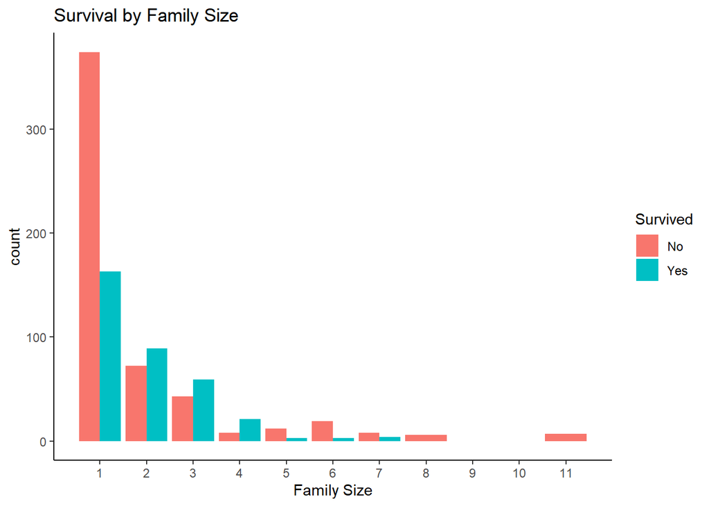

Survival by Family Size

```r
#ggplot2 to visualize
ggplot(full[1:891,], aes(x=Fsize, fill= Survived)) +
  geom_bar(stat="count", position="dodge") +
  scale_x_continuous(breaks=c(1:11)) +
  labs(x="Family Size", title = "Survival by Family Size")
```

It looks like apart from singletons, small families seem to have survived the disaster. Not great for singles and independent people.

Lets create a discreet family size variable.

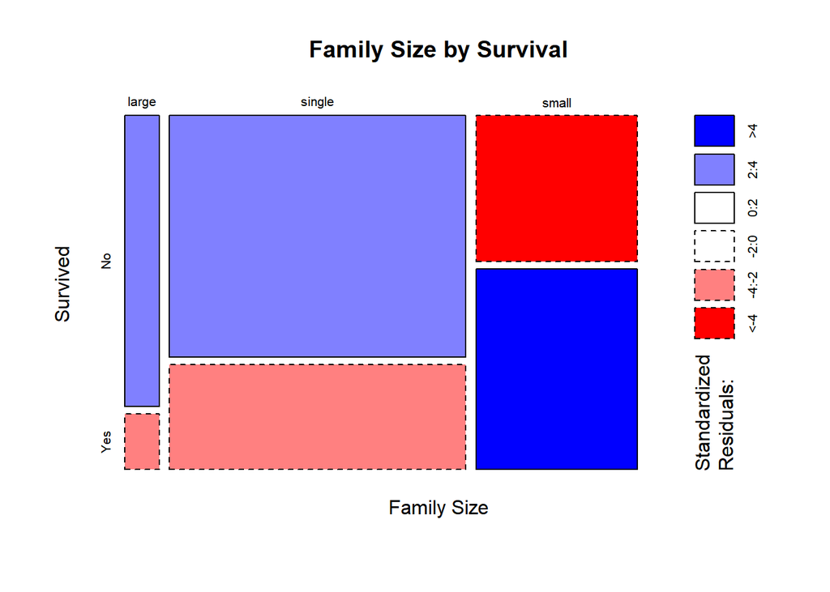

Survival by Family

```r
#Discrete family size
full$FsizeD[full$Fsize == 1] <- "single"
full$FsizeD[full$Fsize < 5 & full$Fsize >1] <- "small"
full$FsizeD[full$Fsize > 4] <- "large"
full$FsizeD <- as.character(full$FsizeD)

#Let's visualize depending on Family Size
mosaicplot(table(full$FsizeD, full$Survived), main= "Family Size by Survival", xlab="Family Size",  ylab="Survived", shade=TRUE)
```

There’s a survival penalty among single and large families, but a benefit for passenger in small families.

### Passenger Cabin

Let’s see if they were in first class or not.

```r
head(full$Cabin)
```

```
## [1] NA     "C85"  NA     "C123" NA     NA
```

```r
# The first character is the deck. For example:
strsplit(full$Cabin[2], NULL)[[1]]
```

```
## [1] "C" "8" "5"
```

```r
# Create a Deck variable. Get passenger deck A - F:
full$Deck<- as.character(factor(sapply(full$Cabin, function(x) strsplit(x, NULL)[[1]][1])))
```

### Missingness

Now we’re ready to start exploring missing data and rectifying it through imputation. There are a number of different ways we could go about doing this. Given the small size of the dataset, we probably should not opt for deleting either entire observations (rows) or variables (columns) containing missing values. We’re left with the option of either replacing missing values with a sensible values given the distribution of the data, e.g., the mean, median or mode. Finally, we could go with prediction. We’ll use both of the two latter methods and I’ll rely on some data visualization to guide our decisions.

```r
skim(full) %>%
  select(-(numeric.p0:numeric.p100)) %>%
  select(-(complete_rate))
```

Data summary

| Name | full |
| --- | --- |
| Number of rows | 1309 |
| Number of columns | 19 |
| _______________________ |  |
| Column type frequency: |  |
| character | 10 |
| factor | 2 |
| numeric | 7 |
| ________________________ |  |
| Group variables | None |

**Variable type: character**

| skim_variable | n_missing | min | max | empty | n_unique | whitespace |
| --- | --- | --- | --- | --- | --- | --- |
| Name | 0 | 12 | 82 | 0 | 1307 | 0 |
| Sex | 0 | 4 | 6 | 0 | 2 | 0 |
| Ticket | 0 | 3 | 18 | 0 | 929 | 0 |
| Cabin | 1014 | 1 | 15 | 0 | 186 | 0 |
| Embarked | 2 | 1 | 1 | 0 | 3 | 0 |
| set | 0 | 4 | 5 | 0 | 2 | 0 |
| Title | 0 | 2 | 10 | 0 | 5 | 0 |
| Surname | 0 | 3 | 22 | 0 | 875 | 0 |
| Family | 0 | 5 | 24 | 0 | 928 | 0 |
| FsizeD | 0 | 5 | 6 | 0 | 3 | 0 |

**Variable type: factor**

| skim_variable | n_missing | ordered | n_unique | top_counts |
| --- | --- | --- | --- | --- |
| Survived | 418 | FALSE | 2 | No: 549, Yes: 342 |
| Deck | 1014 | FALSE | 8 | C: 94, B: 65, D: 46, E: 41 |

**Variable type: numeric**

| skim_variable | n_missing | mean | sd | hist |
| --- | --- | --- | --- | --- |
| PassengerId | 0 | 655.00 | 378.02 | ▇▇▇▇▇ |
| Pclass | 0 | 2.29 | 0.84 | ▃▁▃▁▇ |
| Age | 263 | 29.88 | 14.41 | ▂▇▅▂▁ |
| SibSp | 0 | 0.50 | 1.04 | ▇▁▁▁▁ |
| Parch | 0 | 0.39 | 0.87 | ▇▁▁▁▁ |
| Fare | 1 | 33.30 | 51.76 | ▇▁▁▁▁ |
| Fsize | 0 | 1.88 | 1.58 | ▇▁▁▁▁ |

#### Embarkment

Let’s look at those 2 empty rows on Embarked

```r
kable(filter(full, is.na(Embarked)))
```

| PassengerId | Survived | Pclass | Name | Sex | Age | SibSp | Parch | Ticket | Fare | Cabin | Embarked | set | Title | Surname | Fsize | Family | FsizeD | Deck |
| --- | --- | --- | --- | --- | --- | --- | --- | --- | --- | --- | --- | --- | --- | --- | --- | --- | --- | --- |
| 62 | Yes | 1 | Icard, Miss. Amelie | female | 38 | 0 | 0 | 113572 | 80 | B28 | NA | train | Miss | Icard | 1 | Icard_1 | single | B |
| 830 | Yes | 1 | Stone, Mrs. George Nelson (Martha Evelyn) | female | 62 | 0 | 0 | 113572 | 80 | B28 | NA | train | Mrs | Stone | 1 | Stone_1 | single | B |

```r
cat(paste('We will infer their values for **embarkment** based on present data that we can imagine may be relevant: **passenger class** and **fare**. We see that they paid<b> $', full[c(62, 830), 'Fare'][[1]][1], '</b>and<b> $', full[c(62, 830), 'Fare'][[1]][2], '</b>respectively and their classes are<b>', full[c(62, 830), 'Pclass'][[1]][1], '</b>and<b>', full[c(62, 830), 'Pclass'][[1]][2], '</b>. So from where did they embark?'))
```

```
## We will infer their values for **embarkment** based on present data that we can imagine may be relevant: **passenger class** and **fare**. We see that they paid<b> $ 80 </b>and<b> $ NA </b>respectively and their classes are<b> 1 </b>and<b> NA </b>. So from where did they embark?
```

Lets plot all those passengers that have an embarkment and see how much they paid, we could see from where they could have embarked in.

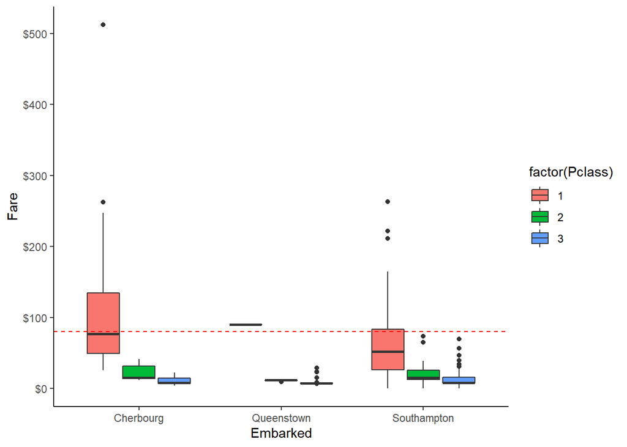

```r
#  Filter so we won't have those passenger in the plot
embark_fare <- full %>%
  filter(PassengerId != 62 & PassengerId != 830)

#Visualize
ggplot(embark_fare, aes(x=Embarked, y=Fare, fill = factor(Pclass))) +
  geom_boxplot()+
  geom_hline(aes(yintercept=80),
             colour= "red", linetype="dashed") + #80 is the fare we got
  scale_y_continuous(labels = dollar_format()) +
  scale_x_discrete(labels = c("Cherbourg", "Queenstown", "Southampton"))
```

So the median fare for a first class passenger departing from Charbourg coincides nicely with the $80 paid by our embarkment-deficient passengers!!! I think we can safely replace the NA values with ‘C’.

```r
# Since their fare was $80 for 1st class, they most likely embarked from 'C'
full$Embarked[c(62, 830)] <- 'C'
```

#### Fare

Now let’s take a look at the missing value on Fare

```r
knitr::kable(filter(full, is.na(Fare)))
```

| PassengerId | Survived | Pclass | Name | Sex | Age | SibSp | Parch | Ticket | Fare | Cabin | Embarked | set | Title | Surname | Fsize | Family | FsizeD | Deck |
| --- | --- | --- | --- | --- | --- | --- | --- | --- | --- | --- | --- | --- | --- | --- | --- | --- | --- | --- |
| 1044 | NA | 3 | Storey, Mr. Thomas | male | 60.5 | 0 | 0 | 3701 | NA | NA | S | test | Mr | Storey | 1 | Storey_1 | single | NA |

This is a third class passenger who departed from Southampton (‘S’). Let’s visualize Fares among all others sharing their class (3) and embarkment (S) (n = 494).

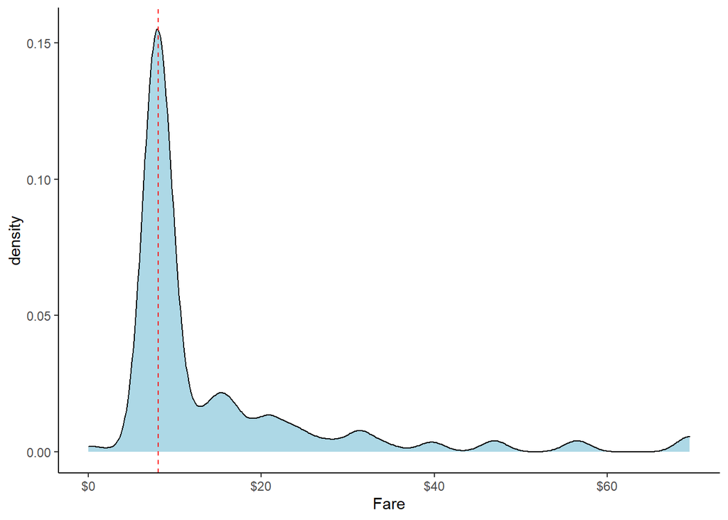

```r
ggplot(full[full$Pclass == "3" & full$Embarked == "S", ],
  aes(x=Fare)) +
  geom_density(fill="lightblue") +
  geom_vline(aes(xintercept=median(Fare, na.rm=T)),
             colour="red", linetype="dashed") +
  theme_classic() +
  scale_x_continuous(labels=dollar_format())
```

From this visualization, it seems quite reasonable to replace the NA Fare value with median for their class and embarkment.

```r
#Replace missing fare value with median fare for class/embarkment
full$Fare[1044] <- median(full[full$Pclass == "3" & full$Embarked == "S",]$Fare, na.rm = TRUE)

#Let's take a look
full$Fare[1044]
```

```
## [1] 8.05
```

#### Ages

There are quite a few missing Age values in our data. We will create a model predicting ages based on other variables.

```r
# Make variables factors into factors
factor_vars <- c('PassengerId','Pclass','Sex','Embarked',
                 'Title','Surname','Family','FsizeD')

full[factor_vars] <- lapply(full[factor_vars], function(x) as.factor(x))

# Set a random seed
set.seed(129)

# Perform mice imputation, excluding certain less-than-useful variables:
mice_mod <- mice(full[, !names(full) %in% c('PassengerId','Name','Ticket','Cabin','Family','Surname','Survived')], method='rf')
# Save the complete output
mice_output <- complete(mice_mod)
```

Let’s compare the results we get with the original distribution of passenger ages to ensure that nothing has gone completely awry.

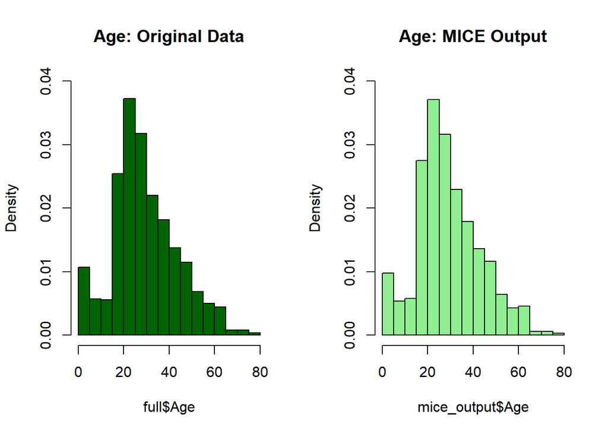

```r
# Plot age distributions
par(mfrow=c(1,2)) #lets divide the plot in 2
hist(full$Age, freq=F, main='Age: Original Data',
  col='darkgreen', ylim=c(0,0.04))
hist(mice_output$Age, freq=F, main='Age: MICE Output',
  col='lightgreen', ylim=c(0,0.04))
```

Let’s replace our age vector in the original data with the output from the mice model.

```r
# Replace Age variable from the mice model.
full$Age <- mice_output$Age
full[factor_vars] <- lapply(full[factor_vars], function(x) as.character(x))

# Show new number of missing Age values
sum(is.na(full$Age))
```

```
## [1] 0
```

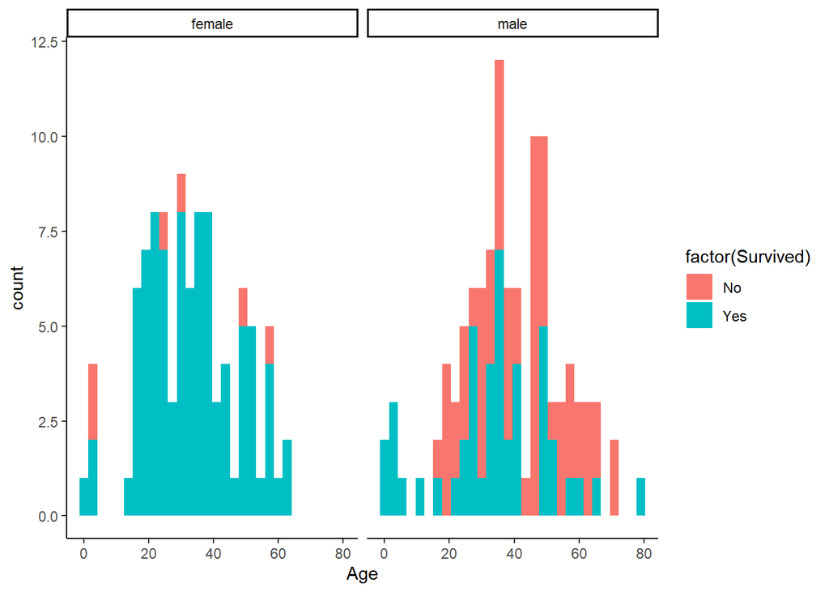

```r
# First we'll look at the relationship between age & survival
ggplot(full %>% filter(set=="train") %>% na.omit,
       aes(Age, fill = factor(Survived))) +
  geom_histogram() +
  # I include Sex since we know (a priori) it's a significant predictor
  facet_grid(.~Sex) +
  theme_classic()
```

```r
# Create the column AgeGroup, and indicate whether is a Child, Young Adult, Adult or Elder
full$AgeGroup[full$Age < 12] <- "Child"
full$AgeGroup[full$Age >= 12 & full$Age < 18] <- "Young"
full$AgeGroup[full$Age >= 18 & full$Age < 60] <- "Adult"
full$AgeGroup[full$Age >= 60] <- "Elder"

# Show counts
kable(table(full$AgeGroup, full$Survived))
```

|  | No | Yes |
| --- | --- | --- |
| Adult | 456 | 265 |
| Child | 38 | 42 |
| Elder | 26 | 7 |
| Young | 29 | 28 |

Yeah, looks like being a toddler won’t necessarily save you! Maybe we can hope that mothers are more likely to have survived on the Titanic.

```r
# Adding Mother variable
full$Mother <- 'Not Mother'
full$Mother[full$Sex == 'female' & full$Parch > 0 & full$Age > 18 & full$Title != 'Miss'] <- 'Mother'
full$Mother <- as.character(full$Mother)

# Show counts
kable(table(full$Mother, full$Survived))
```

|  | No | Yes |
| --- | --- | --- |
| Mother | 15 | 39 |
| Not Mother | 534 | 303 |

Lets create a final table to see how many survived

```r
#lets get only the data with survivors
titanic_survivorrate <- full %>%
  filter(!is.na(Survived)) %>%
  group_by(Survived) %>%
  summarise(n=n()) %>%
  mutate(freq = n/sum(n))

kable(titanic_survivorrate) #table
```

| Survived | n | freq |
| --- | --- | --- |
| No | 549 | 0.6161616 |
| Yes | 342 | 0.3838384 |

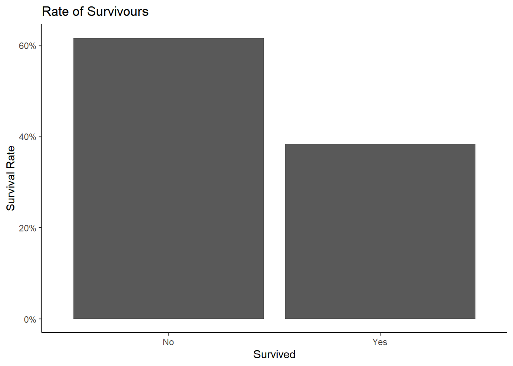

```r
#get only survivors
titanic_onlysurvivors <- titanic_survivorrate$freq[titanic_survivorrate$Survived == "Yes"]

  ggplot(titanic_survivorrate, aes(Survived, freq))+
    geom_col()+
    labs(y="Survival Rate", title="Rate of Survivours") +
    scale_y_continuous(labels = percent)
```

Yeah, a tragedy!

## Data Visualisation!

Go through each tab to visualise different variables and see the relationship to survival rate

### Pclass

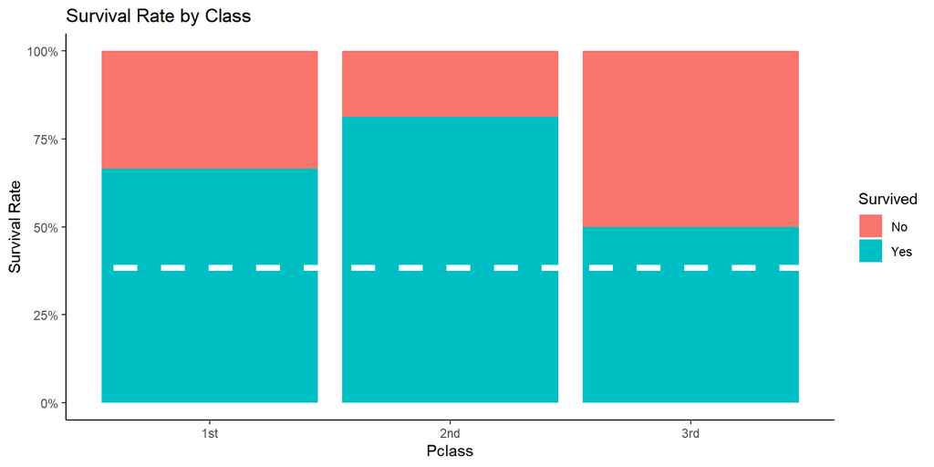

```r
ggplot(full %>% filter(set=="train") %>% na.omit,
       aes(Pclass, fill=Survived)) +
  geom_bar(position="fill") +
  scale_y_continuous(labels = percent) +
  geom_hline(yintercept=titanic_onlysurvivors, col="white", lty=2, size=2)+
  labs(y="Survival Rate", title="Survival Rate by Class") +
  scale_x_discrete(labels= c("1st", "2nd", "3rd"))
```

### Age

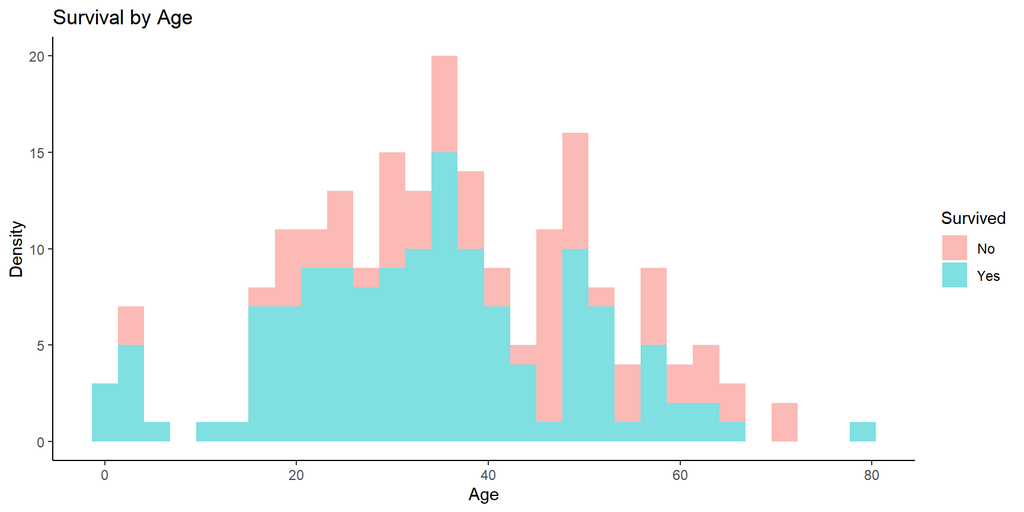

```r
ggplot(full %>% filter(set=="train") %>% na.omit,
       aes(Age, fill=Survived)) +
  geom_histogram(aes(y=..count..), alpha=0.5) +
  labs(y="Density", title="Survival by Age")
```

### Age Group

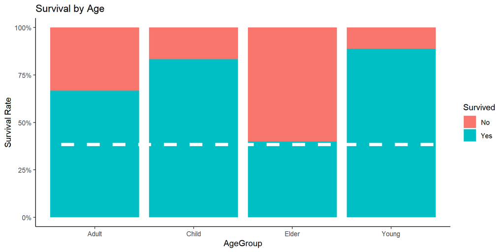

```r
ggplot(full %>% filter(set=="train") %>% na.omit,
       aes(AgeGroup, fill=Survived)) +
  geom_bar(position="fill") +
  scale_y_continuous(labels=percent) +
  geom_hline(yintercept=titanic_onlysurvivors, col="white", lty=2, size=2)+
  labs(y="Survival Rate", title="Survival by Age")
```

### Mother

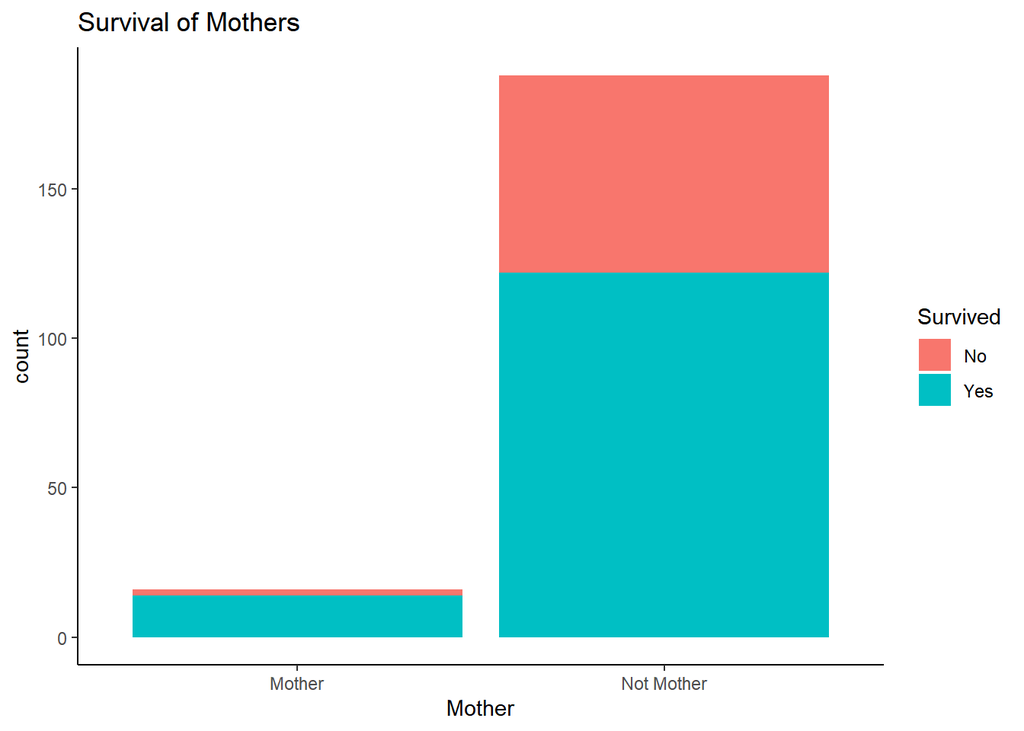

```r
# First we'll look at the relationship between age & survival
ggplot(full %>% filter(set=="train") %>% na.omit, aes(Mother, fill = Survived)) +
  geom_bar() +
  labs(title= "Survival of Mothers")
```

### Siblings

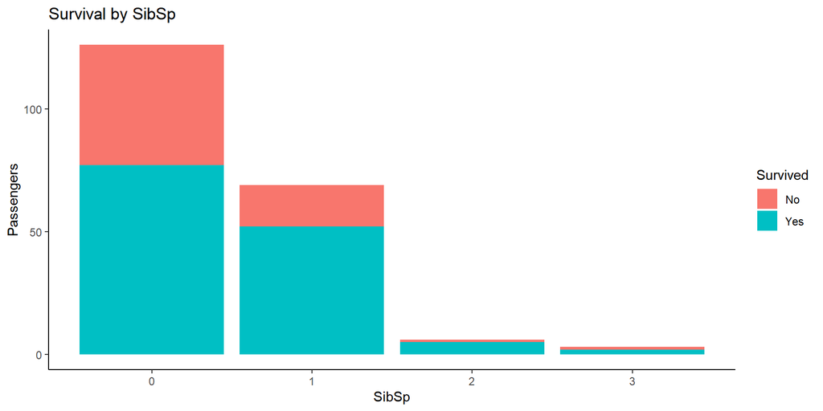

```r
ggplot(full %>% filter(set=="train") %>% na.omit,
       aes(SibSp, fill=Survived)) +
  geom_bar(position="stack") +
  labs(y="Passengers", title="Survival by SibSp")
```

### Embarked

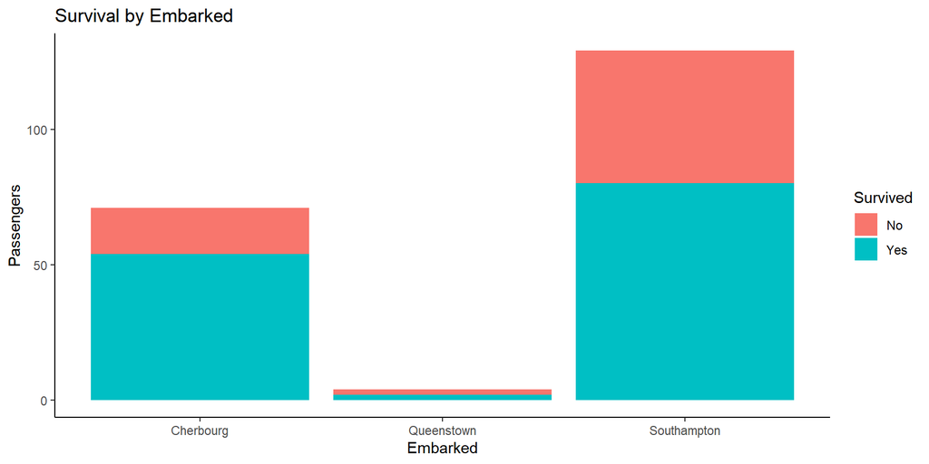

```r
ggplot(full %>% filter(set=="train") %>% na.omit,
       aes(Embarked, fill=Survived)) +
  geom_bar(position="stack") +
  labs(y="Passengers", title="Survival by Embarked") +
  scale_x_discrete(labels= c("Cherbourg", "Queenstown", "Southampton"))
```

### Title

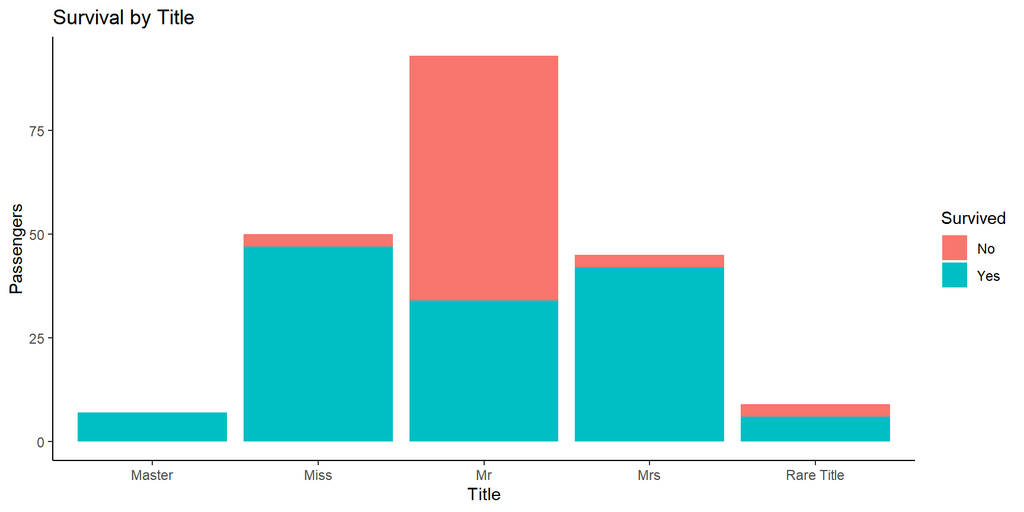

```r
ggplot(full %>% filter(set=="train") %>% na.omit,
       aes(Title, fill=Survived)) +
  geom_bar(position="stack") +
  labs(y="Passengers", title="Survival by Title")
```

### Family Size

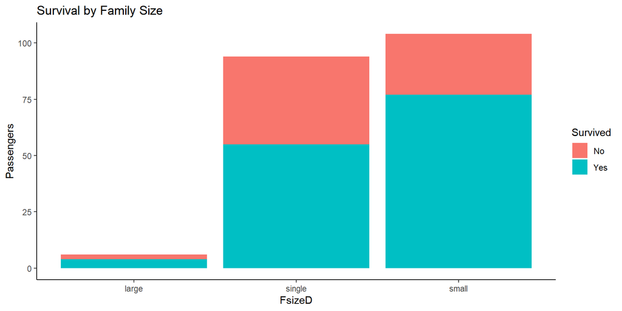

```r
ggplot(full %>% filter(set=="train") %>% na.omit,
       aes(FsizeD, fill=Survived)) +
  geom_bar(position="stack") +
  labs(y="Passengers", title="Survival by Family Size")
```

### Sex

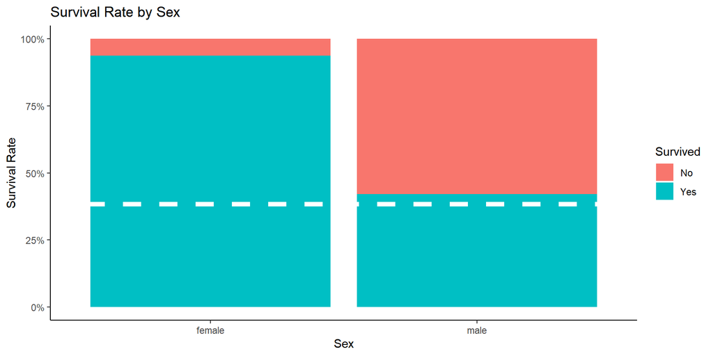

```r
ggplot(full %>% filter(set=="train") %>% na.omit,
       aes(Sex, fill=Survived)) +
  geom_bar(position="fill") +
  scale_y_continuous(labels = percent) +
  geom_hline(yintercept=titanic_onlysurvivors, col="white", lty=2, size=2)+
  labs(y="Survival Rate", title="Survival Rate by Sex")
```

### Title

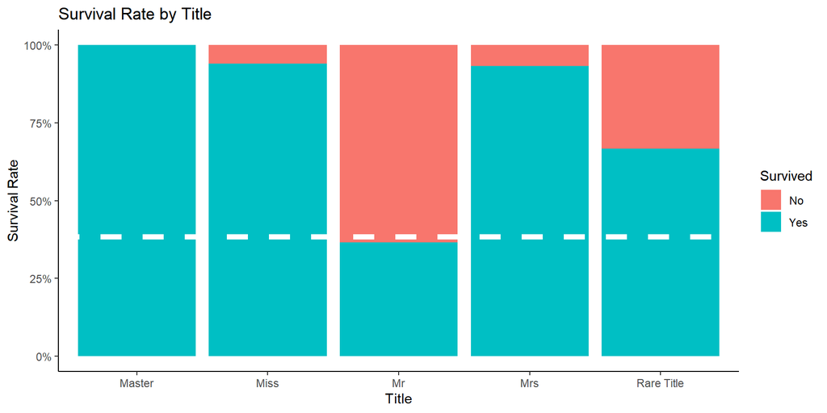

```r
ggplot(full %>% filter(set=="train") %>% na.omit,
       aes(Title, fill=Survived)) +
  geom_bar(position="fill") +
  scale_y_continuous(labels = percent) +
  geom_hline(yintercept=titanic_onlysurvivors, col="white", lty=2, size=2)+
  labs(y="Survival Rate", title="Survival Rate by Title")
```

## Visulize with mosaicplot

A graphical method for visualizing data from qualitative variables.

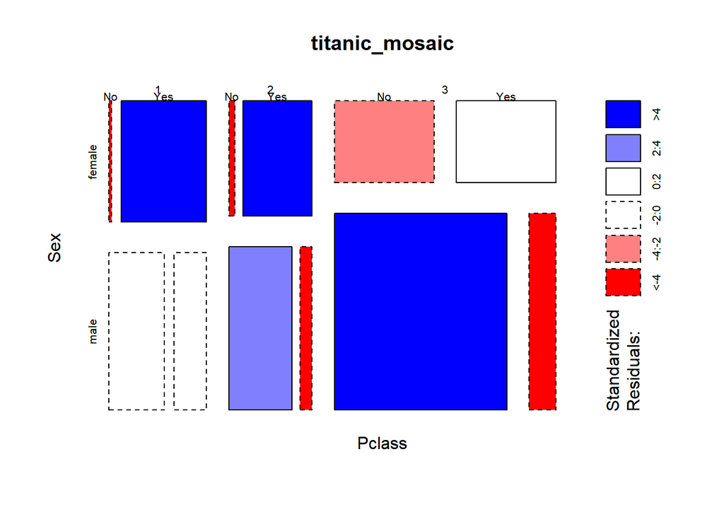

```r
titanic_mosaic <- full %>%
  filter(set=="train") %>%
  select(Survived, Pclass, Sex, AgeGroup, Title, Embarked, FsizeD) %>%
  mutate_all(as.factor)

mosaicplot(~Pclass+Sex+Survived, data=titanic_mosaic, shade=TRUE, legend=TRUE)
```

### lluvial Diagram

We are now ready to predict!

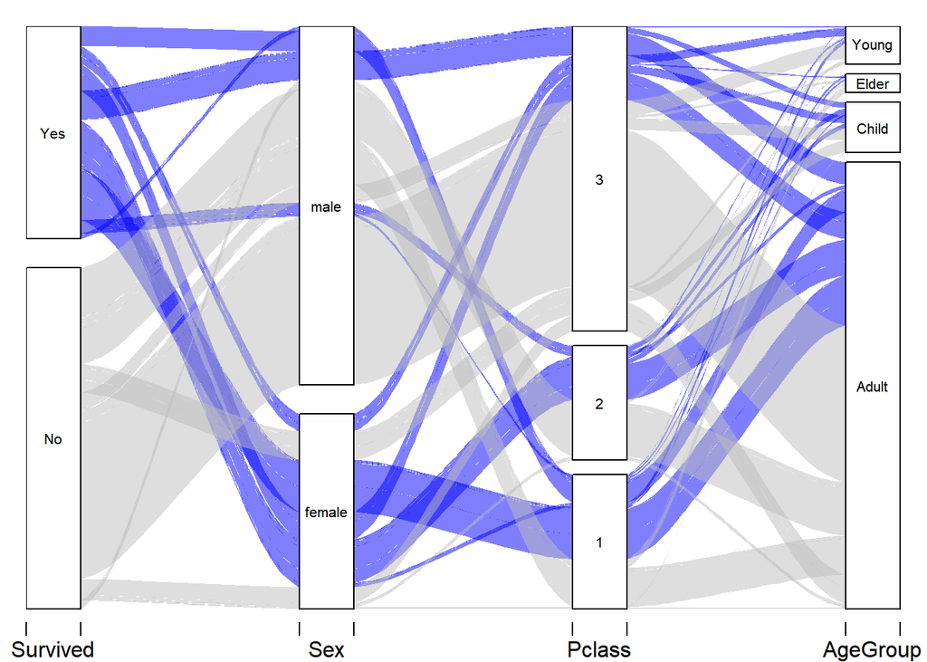

```r
library(alluvial)

tbl_summary <- full %>%
  filter(set=="train") %>%
  group_by(Survived, Sex, Pclass, AgeGroup, Title) %>%
  summarise(N = n()) %>%
  ungroup %>%
  na.omit
alluvial(tbl_summary[, c(1:4)],
         freq=tbl_summary$N, border=NA,
         col=ifelse(tbl_summary$Survived == "Yes", "blue", "gray"),
         cex=0.65,
         ordering = list(
           order(tbl_summary$Survived, tbl_summary$Pclass==1),
           order(tbl_summary$Sex, tbl_summary$Pclass==1),
           NULL,
           NULL))
```

```r
# Split the data back into a train set and a test set
train <- full %>% filter(set=="train")
test <- full %>% filter(set=="test")
```

#### Building the model

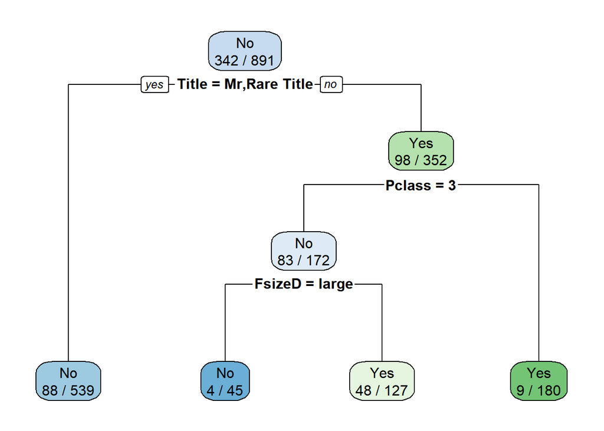

```r
# Growing a tree
set.seed(129)
prep_test<-train%>%
  select(Pclass, Title,Sex,Embarked, FsizeD, Age)
prep_test$Survived <- as.factor(train$Survived)

library(rpart)
library(rpart.plot)
Model_DT=rpart(Survived~.,data=prep_test,method="class")
rpart.plot(Model_DT,extra =  3)
```

```r
prep_test <- as.data.frame(prep_test)

library(caret)
prediction= predict(Model_DT, newdata = test, type="class")
```

```r
rf_model <- randomForest(factor(Survived) ~ Pclass + Sex + Age +  Embarked + Title + FsizeD + AgeGroup, importance = TRUE, data = train, ntree=500)

rf_model
```

```
##
## Call:
##  randomForest(formula = factor(Survived) ~ Pclass + Sex + Age +      Embarked + Title + FsizeD + AgeGroup, data = train, importance = TRUE,      ntree = 500)
##                Type of random forest: classification
##                      Number of trees: 500
## No. of variables tried at each split: 2
##
##         OOB estimate of  error rate: 17.28%
## Confusion matrix:
##      No Yes class.error
## No  499  50  0.09107468
## Yes 104 238  0.30409357
```

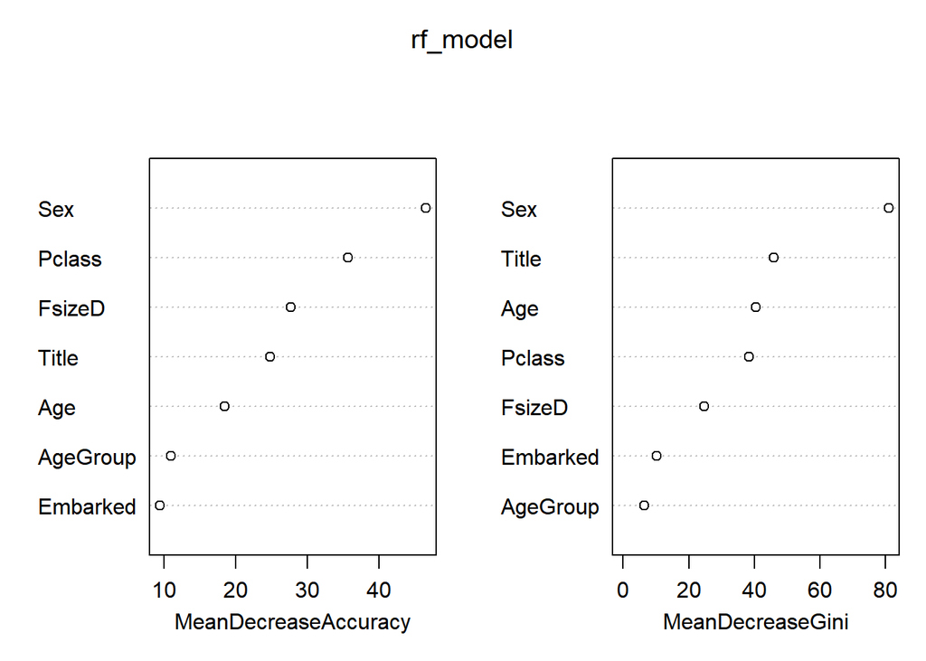

```r
varImpPlot(rf_model)
```

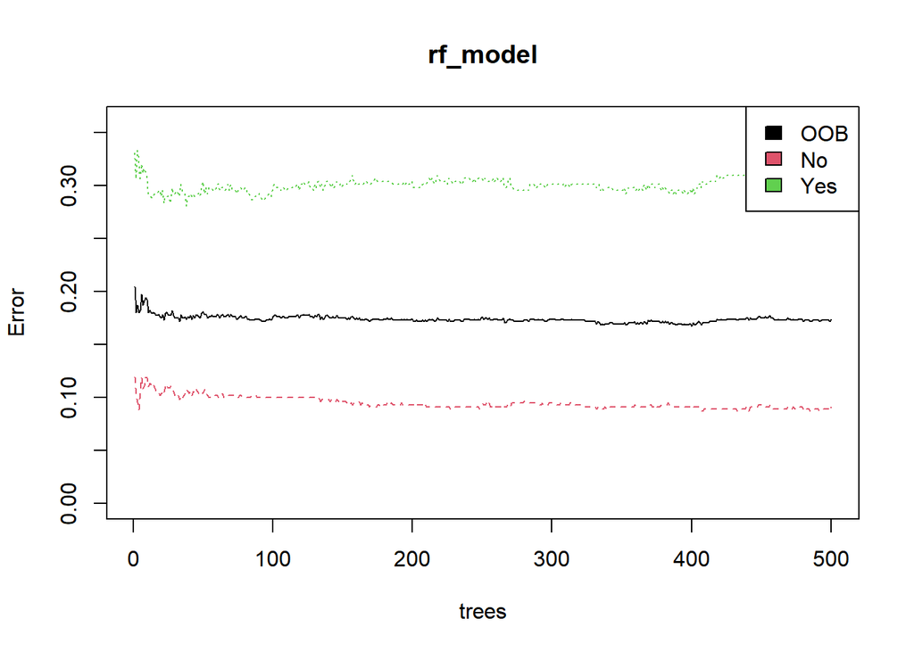

```r
# Show model error
plot(rf_model, ylim=c(0,0.36))
legend('topright', colnames(rf_model$err.rate), col=1:3, fill=1:3)
```

The black line shows the overall error rate which falls below 20%. The red and green lines show the error rate for ‘died’ and ‘survived’ respectively. We can see that right now we’re much more successful predicting death than we are survival.

#### Variable importance

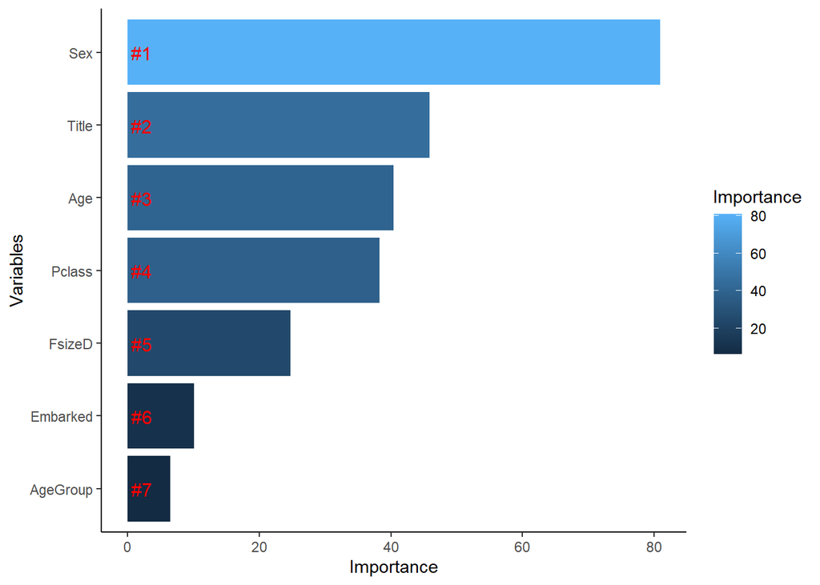

```r
# Get importance
importance    <- importance(rf_model)
varImportance <- data.frame(Variables = row.names(importance),
                            Importance = round(importance[ ,'MeanDecreaseGini'],2))

# Create a rank variable based on importance
rankImportance <- varImportance %>%
  mutate(Rank = paste0('#',dense_rank(desc(Importance))))

# Use ggplot2 to visualize the relative importance of variables
ggplot(rankImportance, aes(x = reorder(Variables, Importance),
    y = Importance, fill = Importance)) +
  geom_bar(stat='identity') +
  geom_text(aes(x = Variables, y = 0.5, label = Rank),
    hjust=0, vjust=0.55, size = 4, colour = 'red') +
  labs(x = 'Variables') +
  coord_flip()
```

## Predict again

#### Predict depending on title

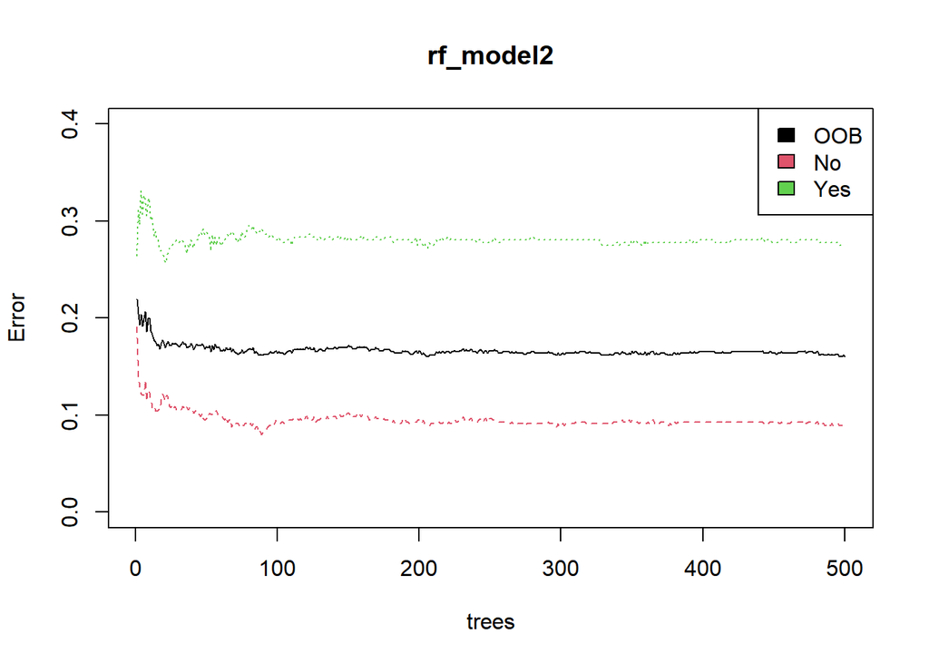

```r
#Build a second model with Pclass, sex, age, SibSp, parch, fare, embarked, title, FsizeD, Child, Mother,
rf_model2<- randomForest(factor(Survived) ~ Title + Fare + Sex + Age + Pclass,
                                            data = train)

# Show model error
plot(rf_model2, ylim=c(0,0.4))
legend('topright', colnames(rf_model2$err.rate), col=1:3, fill=1:3)
```

```r
# Predict using the test set
prediction <- predict(rf_model2, test)

# Save the solution to a dataframe with two columns: PassengerId and Survived (prediction)
solution <- data.frame(PassengerID = test$PassengerId, Survived = prediction)
head(solution)
```

```
##   PassengerID Survived
## 1         892       No
## 2         893       No
## 3         894       No
## 4         895       No
## 5         896      Yes
## 6         897       No
```

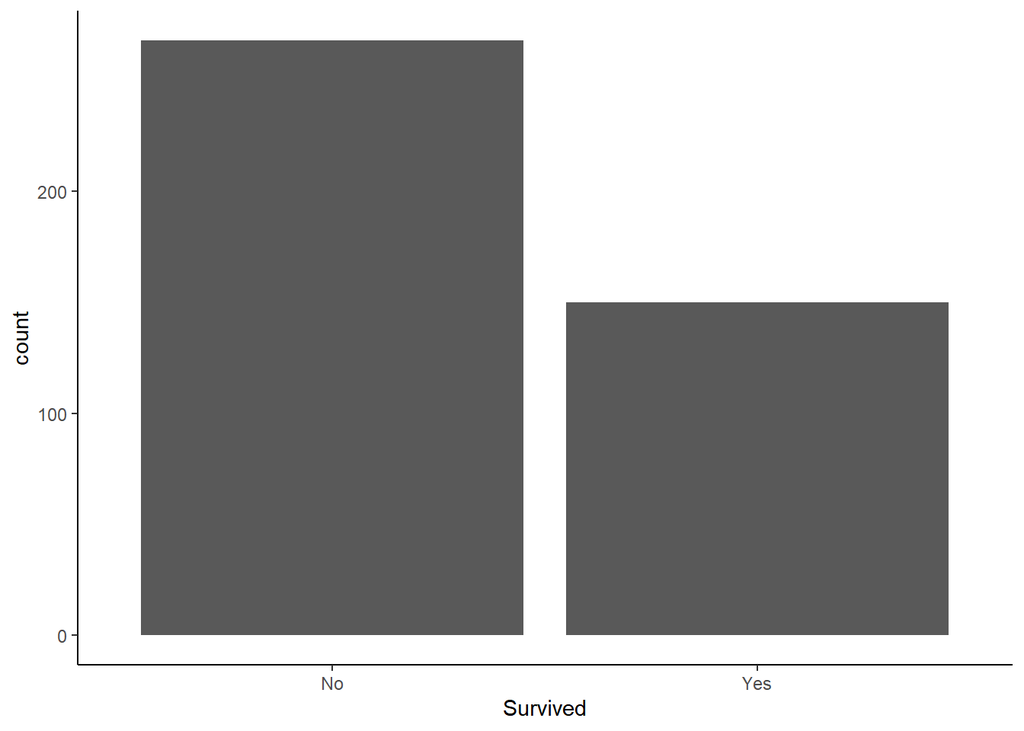

```r
ggplot(solution, aes(Survived))+
  geom_bar()
```

```r
# Write the solution to file
write.csv(solution, file = 'solution.csv', row.names = F)
```